# Statistics 651 Hierarchical Modeling

Winter 2026

## Objectives

1. Formulate hierarchical models to appropriately model stratified data
2. Fit hierarchical models via MCMC
3. Draw from predictive distributions at appropriate population levels
4. Assess whether exhangeability is reasonable in a given scenario
5. Express models for dependent data hierarchically or marginally

## Resources

- BDA3: Ch 5
- BIDA: Ch 4.12–4.13
- Hoff: Ch 8.2–8.5 (great treatment of the normal hierarchical model)

# Stratified data

## Motivation

**Example**

In a recent Utah Jazz game<sup>1</sup>, ten players attempted free throws.

Results: (# made / # attempts)

15/20, 4/7, 3/6, 4/4, 2/4, 10/12, 5/6, 10/12, 2/2, 0/1

Suppose we are interested in:

- Estimating a typical NBA player’s free-throw ability
- Predicting a typical NBA player’s free-throw performance
- Estimating the free-throw ability of the fourth player listed above
- Predicting the free-throw performance of the fourth player listed above
[^1]: Dec 15, 2025 vs the Dallas Mavericks. [Box score](https://www.nba.com/game/dal-vs-uta-0022501224/box-score?cid=nba:organic:onebox:boxscore:global)

## Motivation

**Example (continued)**

Free throws: (# made / # attempts)

15/20, 4/7, 3/6, 4/4, 2/4, 10/12, 5/6, 10/12, 2/2, 0/1

If estimating/predicting for a typical NBA player:

Possible strategies

## Motivation

**Example (continued)**

Free throws: (# made / # attempts)

15/20, 4/7, 3/6, 4/4, 2/4, 10/12, 5/6, 10/12, 2/2, 0/1

If estimating/predicting for the fourth listed player:

What is the maximum-likelihood estimate under a Binomial model? How would you predict??

Would it be appropriate to incorporate the other players’ data to influence your estimate/predictions?

## Motivation

**Example (continued)**

Free throws: (# made / # attempts)

15/20, 4/7, 3/6, 4/4, 2/4, 10/12, 5/6, 10/12, 2/2, 0/1

Estimate/predict for:

- A typical NBA player.
- The fourth player listed above.

Could we address **both** objectives with a single model?

## Motivation

**Example (continued)**

Free throws: (# made / # attempts)

15/20, 4/7, 3/6, 4/4, 2/4, 10/12, 5/6, 10/12, 2/2, 0/1

Estimate/predict for:

- A typical NBA player.
- The fourth player listed above.

Model: $y_i \mid \theta_i \overset{\text{ind}}{\sim} \mbox{Binom}(n_i, \, \theta_i)$

What should the prior for $\theta_i$ look like?

# Hierarchical models

## Hierarchical models

**Model formulation**

Generic model form

$$\begin{align}
\boldsymbol{y} \mid \boldsymbol{\theta} &\sim f(\boldsymbol{y}| \boldsymbol{\theta}) \, , \\
\boldsymbol{\theta} \mid \boldsymbol{\phi} &\sim \pi(\boldsymbol{\theta}| \boldsymbol{\phi}) \, , \\
\boldsymbol{\phi} &\sim \pi_0(\boldsymbol{\phi}) \, ,
\end{align}$$

where $f$ is the **sampling model** with **parameters** $\boldsymbol{\theta}$ and **hyperparameters** $\boldsymbol{\phi}$.

A hierarchical model can be composed of as many levels as necessary.

It is common for $\boldsymbol{y}$ to be conditionally independent of $\boldsymbol{\phi}$ (conditional on $\boldsymbol{\theta}$).

Joint distribution:

## Hierarchical models

**Graphical representation**

Hierarchical models can be visually represented using **directed acyclic graphs** ([DAGs](https://en.wikipedia.org/wiki/Directed_acyclic_graph)), where

- observed stochastic nodes (data) are represented with filled circles,
- unobserved stochastic nodes (parameters) are represented with open circles,
- dependence relationships are represented with arrows connecting nodes, and
- replication is represented with plates.

## Hierarchical models

**DAG example**

Draw a DAG for the hierarchical Binomial free-throw model.

## Hierarchical models

**Conditional independence and DAGs**

DAGs are also useful because conditional-independence structures become apparent by “moralizing” the graph:

1. Two nodes sharing a common immediate descendant are connected with undirected edges.
2. Directional arrows are replaced with undirected edges.
3. Nodes that are separated by common connections with other nodes are independent, conditional on the connecting nodes.

Where would conditional independence be useful?

## Hierarchical models

**Free-throw example**

Show the undirected conditional independence structure for the Binomial free-throw model.

## Hierarchical models

**Example (continued)**

Free throws: (# made / # attempts)

15/20, 4/7, 3/6, 4/4, 2/4, 10/12, 5/6, 10/12, 2/2, 0/1

Fit the model

$$\begin{align}
y_i \mid \theta_i &\overset{\text{ind}}{\sim} \mbox{Binom}(n_i, \theta_i) \, , \quad i = 1, \ldots, n, \\
\theta_i \mid \alpha, \beta &\overset{\text{iid}}{\sim} \mbox{Beta}(\alpha, \beta) \, , \quad i = 1, \ldots, n, \\
(\alpha, \beta) &\sim \Pi_{\alpha, \beta}
\end{align}$$
using

- a full Gibbs sampler
- a PPL

# Predictive distributions

## Predictive distributions

**Example (continued)**

Recall that our original objectives in the free throw example were to:

- Estimate a typical NBA player’s free-throw ability
- Predict a typical NBA player’s free-throw performance
- Estimate the free-throw ability of the fourth player (4/4)
- Predict the free-throw performance of the fourth player (4/4)

Use the model to address each.

## Predictive distributions

**Example (continued)**

1. Estimate the free-throw ability of the fourth player (4/4).

Which quantity do we use here? Compare prior and posterior for this quantity.

## Predictive distributions

**Example (continued)**

2. Predict the performance of the fourth player (4/4) on his next five free throws.

Which quantity do we use here? Compare prior and posterior for this quantity.

## Predictive distributions

**Example (continued)**

3. Estimate a typical NBA player’s free-throw ability.

Which quantity do we use here? Compare prior and posterior for this quantity.

## Predictive distributions

**Example (continued)**

4. Predict the performance of a typical NBA player on his next five free throws.

Which quantity do we use here? Compare prior and posterior for this quantity.

## Predictive distributions

What happens if we just plug in $\mathbb{E}(\theta^* \mid \alpha, \beta)$ for $\theta^*$ when estimating the predictive distribution of $y^*$?

# Collapsed (marginal) hierarchical models

## Collapsed hierarchical models

**Marginal likelihood**

The hierarchical model

$$\begin{align}
\boldsymbol{y} \mid \boldsymbol{\theta} &\sim f(\boldsymbol{y}| \boldsymbol{\theta}) \, , \\
\boldsymbol{\theta} \mid \boldsymbol{\phi} &\sim \pi(\boldsymbol{\theta}| \boldsymbol{\phi}) \, \\
\end{align}$$

is equivalent to modeling

$$f_\text{marg}(\boldsymbol{y}| \boldsymbol{\phi}) = \int f(\boldsymbol{y}| \boldsymbol{\theta}) \, \pi(\boldsymbol{\theta}| \boldsymbol{\phi}) \, \mbox{d}\boldsymbol{\theta}$$
directly.

Joint distribution of $(\boldsymbol{y}, \boldsymbol{\phi})$:

## Marginal model

**Joint posterior distribution**

$\pi(\boldsymbol{\theta}, \boldsymbol{\phi} \mid \boldsymbol{y}) =$

MCMC can proceed by targeting $\pi(\boldsymbol{\theta}, \boldsymbol{\phi} \mid \boldsymbol{y})$ all at once (as STAN does using HMC) or by Gibbs sampling.

Sometimes it is a good idea to sample the **collapsed** posterior, if possible:

$\pi(\boldsymbol{\phi} \mid \boldsymbol{y}) =$

## Marginal model

**Example (continued)**

Free throws: (# made / # attempts)

15/20, 4/7, 3/6, 4/4, 2/4, 10/12, 5/6, 10/12, 2/2, 0/1

Fit the model

$$\begin{align}
y_i \mid \theta_i &\overset{\text{ind}}{\sim} \mbox{Binom}(n_i, \theta_i) \, , \quad i = 1, \ldots, n, \\
\theta_i \mid \alpha, \beta &\overset{\text{iid}}{\sim} \mbox{Beta}(\alpha, \beta) \, , \quad i = 1, \ldots, n, \\
(\alpha, \beta) &\sim \Pi_{\alpha, \beta}
\end{align}$$
using a collapsed Gibbs sampler.

Compare results with the full Gibbs sampler.

# Exchangeability

## Exchangeability

**Example (continued)**

Free throws: (# made / # attempts)

15/20, 4/7, 3/6, 4/4, 2/4, 10/12, 5/6, 10/12, 2/2, 0/1

Is there any reason we should consider a $\theta_i$ NOT interchangeable with the others in the model?

## Exchangeability

**Example**

Five participants in a survey were asked if they were generally happy.

Let $X_i = 1$ if they responded positively and 0 otherwise.

Suppose we must assign probabilities to each of the following sequences:

$$\begin{gather}
\mathbb{P}(1,1,0,0,1)=? \\
\mathbb{P}(1,0,1,0,1)=? \\
\mathbb{P}(1,0,1,1,0)=?
\end{gather}$$
Is there any argument for assigning distinct values?

## Exchangeability

**Definition**

A sequence of random variables, $X_1, X_2, \ldots$ with $X_i \in \mathcal{X}$ is considered **exchangeable** if its joint distribution is invariant to permutation of the indices. That is,
$$\mathbb{P}(X_1 \in A_1, X_2 \in A_2, \ldots) = \mathbb{P}(X_{\sigma(1)} \in A_1, X_{\sigma(2)} \in A_2, \ldots)$$
for all $A_i \in \mathcal{B}(\mathcal{X})$, where $\sigma(\cdot)$ is any function that permutes the indexes.

## Exchangeability

**Example (continued)**

Five participants in a survey were asked if they were generally happy.

Let $X_i = 1$ if they responded positively and 0 otherwise.

Consider the following:

$$\begin{gather}
\mathbb{P}(X_5 = 1) = a \\
\mathbb{P}(X_5 = 1 \mid X_1 = 1, \ldots, X_4 = 1) = b \\
\end{gather}$$
Should we have $a = b$, $a > b$, or $a < b$?

If $a \ne b$, then $X_5$ is not independent of $X_1, \ldots, X_4$.

## Exchangeability

**Example (continued)**

Five participants in a survey were asked if they were generally happy.

Let $X_i = 1$ if they responded positively and 0 otherwise.

Now suppose we know the “rate of happiness” $\theta \in [0,1]$ in the population and that

$$\begin{gather}
\mathbb{P}(X_i = 1 \mid \theta) = \theta \, , \\
\mathbb{P}(X_i = 1 \mid X_{j \ne i}, \, \theta) = \theta \, .
\end{gather}$$

Then $\{X_i\}$ are **conditionally independent** given $\theta$ and

$$\mathbb{P}(X_1 = x_1, \ldots, X_5 = x_5 \mid \theta) = \theta^{\sum x_i} (1 - \theta)^{5 - \sum x_i} \, .$$

## Exchangeability

**Example (continued)**

Five participants in a survey were asked if they were generally happy.

Let $X_i = 1$ if they responded positively and 0 otherwise.

If $\Pi$ represents our beliefs about $\theta$, then the marginal distribution of $X_1, \ldots, X_5$ is

$\mathbb{P}(X_1 = x_1, \ldots, X_5 = x_5) =$

and

$\mathbb{P}(1,1,0,0,1)=$

$\mathbb{P}(1,0,1,0,1)=$

$\mathbb{P}(1,0,1,1,0)=$

## Exchangeability

**Example (continued)**

Starting with conditional independence (conditioning on $\theta$) and mixing over uncertainty in $\theta$ gives

$$\begin{align}
\mathbb{P}(X_1 = x_1, \ldots, X_n = x_n) &= \int \left[ \prod_{i=1}^n p(x_i \mid \theta) \right] \Pi(\mbox{d}\theta) \\
&= \int \left[ \prod_{i=1}^n p(x_{\sigma(i)} \mid \theta) \right] \Pi(\mbox{d}\theta) \\
&= \mathbb{P}(X_1 = x_{\sigma(1)}, \ldots, X_n = x_{\sigma(n)}) \, ,
\end{align}$$
an exchangeable marginal distribution.

What about the reverse?

## de Finetti’s theorem

**0-1 Representation Theorem (de Finetti, 1935)**

The infinite sequence of binary random variables $X_1, X_2, \ldots$ is exchangeable iff there exists a distribution function $\Pi$ such that for all $n$, the joint probability distribution of $(X_1, \ldots, X_n)$ has a mixture model representation
$$\mathbb{P}(X_1 = x_1, \ldots, X_n = x_n) = \int \left[ \prod_{i=1}^n \theta^{x_i} (1 - \theta)^{1 - x_i} \right] \Pi(\mbox{d}\theta) \, ,$$
where $\Pi(\cdot)$ is the distribution function such that
$$\Pi(\theta) = \lim_{n \rightarrow \infty} \mathbb{P}\left( \frac{1}{n} \sum_{i = 1}^n X_i \le \theta \right) \, ,$$
which is referred to as de Finetti’s measure.

See [Heath & Sudderth (1976)](https://www.tandfonline.com/doi/abs/10.1080/00031305.1976.10479175) for a proof.

## de Finetti’s theorem

The representation theorem extends beyond binary random variables (see [Schervish, 1995](https://link.springer.com/book/10.1007/978-1-4612-4250-5); [Diaconis, 1988](https://midas.mat.uc.cl/STAT651/Lectures/Lecture6/Diaconis1988.pdf))

**Implications**:

- Assume exchangeability $\rightarrow$ mixture representation of conditional iid distributions with “parameters” and a “prior”
- Corollary:
  $$\begin{align}
  \mathbb{P}(X_{n+1} = x_{n+1}, &\ldots, X_{n+m} = x_{n+m} \mid x_1, \ldots, x_n) \\
  &= \int \left[ \prod_{i = n+1}^{n+m} p(x_i \mid \theta) \right] \Pi(\mbox{d}\theta \mid x_1, \ldots, x_n)
  \end{align}$$
- Hierarchical models are typically built on conditional independence

# Hierarchical dependence

## Hierarchical dependence

Note that exchangeability is a *weaker* assumption than independence.

In fact, exchangeability does *not* imply independence.

The mixture structure *induces* dependence among $\{X_i\}$.

Bayesians often refer to this dependence from hierarchical modeling as **borrowing strength**.

- Priors and hierarchical structure provide built-in **regularization** and **shrinkage**

## Hierarchical dependence

**Example (continued)**

Free-throw model:
$$\begin{align}
y_i \mid \theta_i &\overset{\text{ind}}{\sim} \mbox{Binom}(n_i, \theta_i) \, , \quad i = 1, \ldots, n, \\
\theta_i \mid \alpha, \beta &\overset{\text{iid}}{\sim} \mbox{Beta}(\alpha, \beta) \, , \quad i = 1, \ldots, n, \\
(\alpha, \beta) &\sim \Pi_{\alpha, \beta} \, .
\end{align}$$

Where are we assuming exchangeability?

## Hierarchical dependence

**Example (continued)**

Free throws: Verify dependence among the $\{ \theta_i \}$ in the marginal prior.

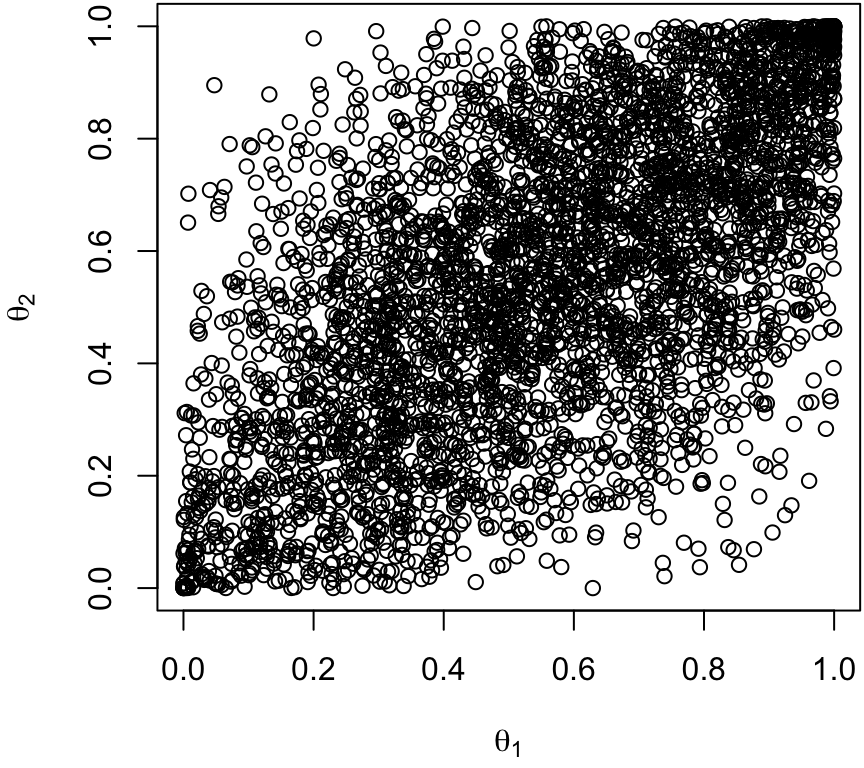

```r
nsim <- 4e3

sh_M <- 7.0
sc_M <- 1.0

sh1_mu <- 2.5
sh2_mu <- 2.0

psim_M <- rgamma(nsim, shape = sh_M, scale = sc_M)
psim_mu <- rbeta(nsim, shape1 = sh1_mu, shape2 = sh2_mu)

psim_theta <- matrix(NA, ncol = 2, nrow = nsim)

for (i in 1:nsim) {
  alpha <- psim_M[i] * psim_mu[i]
  beta <- psim_M[i] * (1.0 - psim_mu[i])
  psim_theta[i,] <- rbeta(2, shape1 = alpha, shape2 = beta)
}

par(mar = c(4.1, 4.1, 0.1, 0.1))
plot(psim_theta, xlab = expression(theta[1]), ylab = expression(theta[2]))
```

## Hierarchical dependence

**Example (continued)**

Free throws: (# made / # attempts)

Compare the (marginal) posterior distributions of $\{\theta_i\}$ with the empirical proportions $\{ y_i/n_i \}$.

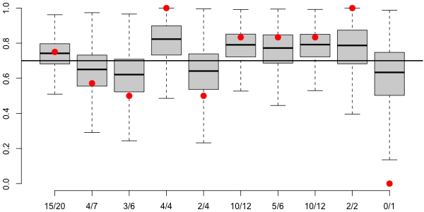

## Hierarchical dependence

**Example (continued)**

Free throws: (# made / # attempts)

Which of Player 4 (4/4) or Player 6 (10/12) do you think is a better free-throw shooter?

## Exchangeability

What might “break” an assumption of exchangeability?

What could we do about it?

# Hierarchical Normal model

## Normal model

The hierarchical normal model is useful because

- Marginal distributions / covariances are analytically available
- Amenable to theoretical study
- Forms the basis for common regression / mixed models
- Applies broadly because of Central Limit Theorem

## Normal model

**Hierarchical means ANOVA model**

Consider the model
$$\begin{align}
y_{i,j} \mid \theta_j, \, \sigma^2 &\overset{\text{ind}}{\sim} \mbox{Normal}(\theta_j, \, \sigma^2) \, , \quad i = 1, \ldots, n_j, \quad j = 1, \ldots, J, \\
\theta_j \mid \mu, \, \tau^2 &\overset{\text{iid}}{\sim} \mbox{Normal}(\mu, \, \tau^2) \, , \quad j = 1, \ldots, J, \\
(\mu, \tau^2, \sigma^2) &\sim \Pi_{\mu, \tau^2, \sigma^2} \, .
\end{align}$$

Potential uses?

## Normal model

**Hierarchical means ANOVA model**

$$\begin{align}
y_{i,j} \mid \theta_j, \, \sigma^2 &\overset{\text{ind}}{\sim} \mbox{Normal}(\theta_j, \, \sigma^2) \, , \quad i = 1, \ldots, n_j, \quad j = 1, \ldots, J, \\
\theta_j \mid \mu, \, \tau^2 &\overset{\text{iid}}{\sim} \mbox{Normal}(\mu, \, \tau^2) \, , \quad j = 1, \ldots, J, \\
(\mu, \tau^2, \sigma^2) &\sim \Pi_{\mu, \tau^2, \sigma^2} \, .
\end{align}$$

Interpretation of $\theta_j$:

Interpretation of $\sigma$:

Interpretation of $\mu$:

Interpretation of $\tau$:

## Normal model

**Hierarchical means ANOVA model**

$$\begin{align}
y_{i,j} \mid \theta_j, \, \sigma^2 &\overset{\text{ind}}{\sim} \mbox{Normal}(\theta_j, \, \sigma^2) \, , \quad i = 1, \ldots, n_j, \quad j = 1, \ldots, J, \\
\theta_j \mid \mu, \, \tau^2 &\overset{\text{iid}}{\sim} \mbox{Normal}(\mu, \, \tau^2) \, , \quad j = 1, \ldots, J.
\end{align}$$

What happens as $\tau \rightarrow \infty$?

What happens as $\tau \rightarrow 0$?

## Normal model

**Hierarchical means ANOVA model**

$$\begin{align}
y_{i,j} \mid \theta_j, \, \sigma^2 &\overset{\text{ind}}{\sim} \mbox{Normal}(\theta_j, \, \sigma^2) \, , \quad i = 1, \ldots, n_j, \quad j = 1, \ldots, J, \\
\theta_j \mid \mu, \, \tau^2 &\overset{\text{iid}}{\sim} \mbox{Normal}(\mu, \, \tau^2) \, , \quad j = 1, \ldots, J, \\
(\mu, \tau^2, \sigma^2) &\sim \Pi_{\mu, \tau^2, \sigma^2} \, .
\end{align}$$

Find:

1. The marginal sampling model of $y_{i,j} \mid ( \sigma^2, \mu, \tau^2)$
2. $\mbox{Cov}(y_{i,j}, y_{i',j} \mid \theta_i \, , \sigma^2, \mu, \tau^2)$
3. $\mbox{Cov}(y_{i,j}, y_{i',j} \mid \sigma^2, \mu, \tau^2)$
4. $\mbox{Cov}(y_{i,j}, y_{i',j'} \mid \theta_j \, , \theta_{j'} \, , \sigma^2, \mu, \tau^2)$
5. $\mbox{Cov}(y_{i,j}, y_{i',j'} \mid \sigma^2, \mu, \tau^2)$

## Normal model

**Hierarchical means ANOVA model**

$$\begin{align}
y_{i,j} \mid \theta_j, \, \sigma^2 &\overset{\text{ind}}{\sim} \mbox{Normal}(\theta_j, \, \sigma^2) \, , \quad i = 1, \ldots, n_j, \quad j = 1, \ldots, J, \\
\theta_j \mid \mu, \, \tau^2 &\overset{\text{iid}}{\sim} \mbox{Normal}(\mu, \, \tau^2) \, , \quad j = 1, \ldots, J, \\
(\mu, \tau^2, \sigma^2) &\sim \Pi_{\mu, \tau^2, \sigma^2} \, .
\end{align}$$

Assume $\mu \sim \mbox{Normal}(m_0, V_0)$, $\tau^2 \sim \mbox{Inv-Gamma}(a_\tau, b_\tau)$, $\sigma^2 \sim \mbox{Inv-Gamma}(a_\sigma, b_\sigma)$.

1. Write the full joint distribution of everything.
2. Derive the complete conditionals for a Gibbs sampler.
3. What other priors for $\tau^2$ and $\sigma^2$ might we choose?

## Normal model

**Hierarchical means (and variances) ANOVA model**

A natural extension:
$$\begin{align}
y_{i,j} \mid \theta_j, \, \sigma_j^2 &\overset{\text{ind}}{\sim} \mbox{Normal}(\theta_j, \, \sigma_j^2) \, , \quad i = 1, \ldots, n_j, \quad j = 1, \ldots, J, \\
(\theta_j \, , \sigma_j^2) \mid \mu, \, \tau^2, \, \boldsymbol{\psi} &\overset{\text{iid}}{\sim} \mbox{Normal}(\mu, \, \tau^2) \times \Pi(\sigma^2 \mid \boldsymbol{\psi}) \, , \quad j = 1, \ldots, J, \\
(\mu, \tau^2, \boldsymbol{\psi}) &\sim \Pi_{\mu, \tau^2, \boldsymbol{\psi}} \, .
\end{align}$$

Choices for $\Pi(\sigma^2 \mid \boldsymbol{\psi})$?

# Model structure as latent variables

## Latent model selection

Hierarchical models can also be used to express discrete model selection

$$\begin{align}
\boldsymbol{y} \mid \boldsymbol{\theta}^{(m)}, Z = m &\sim f_m(\boldsymbol{y}| \boldsymbol{\theta}^{(m)}) \, , \\
\boldsymbol{\theta}^{(m)} \mid Z = m &\sim \pi_m(\boldsymbol{\theta}^{(m)}) \, , \\
Z &\sim \pi_0(z) \, ,
\end{align}$$
where $Z$ is a latent variable indicating the active model among $M$ choices.

**Warning**

We can easily evaluate the posterior for $Z$ if $\pi_m$ and $f_m$ are conjugate.

Otherwise, specialized MCMC (such as [Reversible Jump](https://doi.org/10.1093/biomet/82.4.711)) may be necessary to sample $\boldsymbol{\theta}^{(m)}$, which may change dimension with $m$.

## Latent model selection

**Example**

[Carlin et al., (1992)](https://doi.org/10.2307/2347570) analyze a time series of coal-mining disasters in Great Britain between 1851 and 1962 (reported by [Maguire et al., 1952](https://www.jstor.org/stable/2332475) and [Jarrett, 1979](https://doi.org/10.1093/biomet/66.1.191); available in [boot](https://cran.r-project.org/web/packages/boot/index.html) CRAN package).

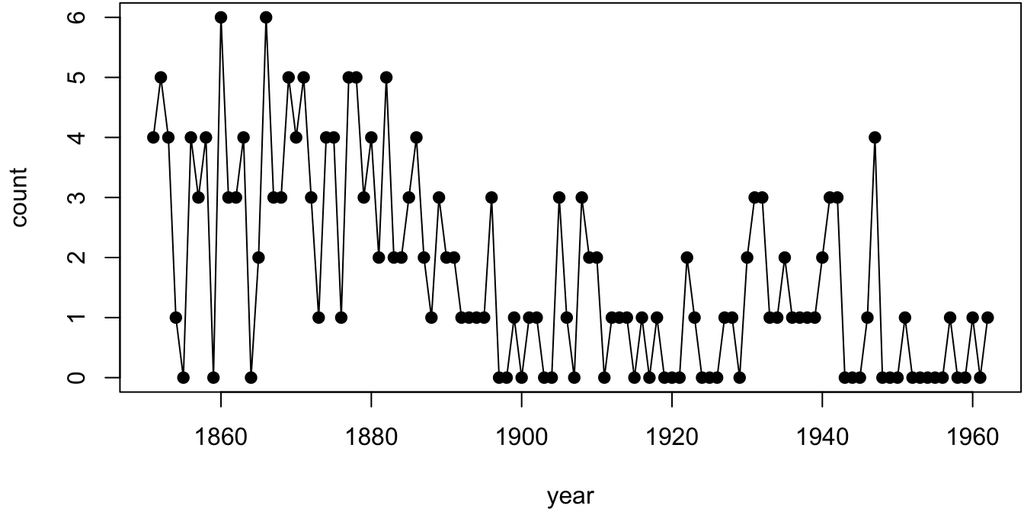

```r
data("coal") # from the boot package on CRAN
yrs <- floor(coal$date)
year_seq <- min(yrs):max(yrs)
dat <- data.frame(year = year_seq,
                  count = as.numeric(table(factor(yrs, levels = year_seq))))

par(mar = c(4.1, 4.1, 0.1, 0.1))
plot(dat, type = "l")
points(dat, pch = 19)
```

## Latent model selection

**Example (continued)**

[Carlin et al., (1992)](https://doi.org/10.2307/2347570) propose to model the counts as Poisson with a change point:

$$\begin{align}
y_t \mid \theta, Z &\overset{\text{iid}}{\sim} \mbox{Poisson}(\theta) \, , \quad t = 1, \ldots, Z, \\
y_t \mid \lambda, Z &\overset{\text{iid}}{\sim} \mbox{Poisson}(\lambda) \, , \quad t = Z+1, \ldots, T, \\
\theta \mid a_\theta, \gamma_\theta &\sim \mbox{Gamma}(a_\theta, \texttt{rate} = \gamma_\theta) \, , \\
\lambda \mid a_\lambda, \gamma_\lambda &\sim \mbox{Gamma}(a_\lambda, \texttt{rate} = \gamma_\lambda) \, , \\
Z &\sim \mbox{Uniform}(\{0, 1, 2, \ldots, T \}) \, ,
\end{align}$$

where $T = 112$. They complete the model with gamma priors on $\gamma_\theta$ and $\gamma_\lambda$.

Can you spot any potential problems with model identifiability? How might we address them?

## Latent model selection

**Example (continued)**

[Carlin et al., (1992)](https://doi.org/10.2307/2347570) propose to model the counts as Poisson with a change point:

$$\begin{align}
y_t \mid \theta, Z &\overset{\text{iid}}{\sim} \mbox{Poisson}(\theta) \, , \quad t = 1, \ldots, Z, \\
y_t \mid \lambda, Z &\overset{\text{iid}}{\sim} \mbox{Poisson}(\lambda) \, , \quad t = Z+1, \ldots, T, \\
\theta \mid a_\theta, \gamma_\theta &\sim \mbox{Gamma}(a_\theta, \texttt{rate} = \gamma_\theta) \, , \\
\lambda \mid a_\lambda, \gamma_\lambda &\sim \mbox{Gamma}(a_\lambda, \texttt{rate} = \gamma_\lambda) \, , \\
Z &\sim \mbox{Uniform}(\{0, 1, 2, \ldots, T \}) \, .
\end{align}$$

1. Write the full joint distribution of everything.
2. Derive the complete conditionals for a Gibbs sampler.
3. Derive a collapsed Gibbs update for $Z$ (integrating out $\theta$ and $\lambda$).

## Latent model selection

**Example (continued)**

[Carlin et al., (1992)](https://doi.org/10.2307/2347570) propose to model the counts as Poisson with a change point:

$$\begin{align}
y_t \mid \theta, Z &\overset{\text{iid}}{\sim} \mbox{Poisson}(\theta) \, , \quad t = 1, \ldots, Z, \\
y_t \mid \lambda, Z &\overset{\text{iid}}{\sim} \mbox{Poisson}(\lambda) \, , \quad t = Z+1, \ldots, T, \\
\theta \mid a_\theta, \gamma_\theta &\sim \mbox{Gamma}(a_\theta, \texttt{rate} = \gamma_\theta) \, , \\
\lambda \mid a_\lambda, \gamma_\lambda &\sim \mbox{Gamma}(a_\lambda, \texttt{rate} = \gamma_\lambda) \, , \\
Z &\sim \mbox{Uniform}(\{0, 1, 2, \ldots, T \}) \, .
\end{align}$$

The model above is *far* from the only choice available to us.

What other model structures might make sense?